# 1 IPython notebook hints and tips

This notebook forms part of a series on [computational optical radiometry](https://github.com/NelisW/ComputationalRadiometry#computational-optical-radiometry-with-pyradi). The notebooks can be downloaded from [Github](https://github.com/NelisW/ComputationalRadiometry#computational-optical-radiometry-with-pyradi). These notebooks are constantly revised and updated, please revisit from time to time.

The date of this document and module versions used in this document are given at the end of the file.  
Feedback is appreciated: neliswillers at gmail dot com.

## Overview

This notebook provides a brief summary of how to start up and use the IPython notebook. Introductions are given to magic commands, help functionality, using IPython for scientific work, cell memory, markdown, citations, embedding media files, and a few lesser used functions.

```python
from IPython.display import display
from IPython.display import Image
from IPython.display import HTML
```

## Learning Python, and hints and tips

There are many free [books](http://docs.python-guide.org/en/latest/intro/learning/), [classes](https://developers.google.com/edu/python/), [blogs](http://www.python.org/about/gettingstarted/) websites and tutorial videos, [more videos](http://pyvideo.org/) and [conferences](http://www.python.org/community/workshops). Material for Numpy is less bountiful, but the [numpy reference]](http://docs.scipy.org/doc/numpy/numpy-ref-1.8.0.pdf) and StackOverflow are good sources. Just google some variation of 'learning python' and make your choice.

See Steve Holden's [Intermediate Python](http://holdenweb.blogspot.com/2014/04/intermediate-python-open-source.html) page. HTML rendering of Steve's notebooks [here](http://nbviewer.ipython.org/github/DevTeam-TheOpenBastion/int-py-notes/tree/master/nbsource/). IPython notebooks [here](https://github.com/DevTeam-TheOpenBastion/int-py-notes/tree/master/nbsource). See the YouTube [video](https://www.youtube.com/watch?v=JYK_8iK2zsw).

http://sahandsaba.com/thirty-python-language-features-and-tricks-you-may-not-know.html

## Introducing Python for scientific work

A very good introduction to Python for scientific work are the [two books](http://folk.uio.no/hpl/scripting/book_comparison.html) by Hans Petter Langtangen.

http://cyrille.rossant.net/why-using-python-for-scientific-computing/ why use Python?  
http://cyrille.rossant.net/tag/ipython/ Python weaknesses - a balanced view  
http://www.numpy.org/  
http://www.scipy.org/  
http://jonathanstreet.com/media/PyNorthwest_Dec2011_Numpy.pdf  
http://www-personal.umich.edu/~kundeng/stats607/week_5_pysci-03-scipy.pdf [nice presentation!]  
http://scipy-lectures.github.io/  
http://www.engr.ucsb.edu/~shell/che210d/python.pdf  
https://github.com/jakevdp/2013_fall_ASTR599 Jake VanderPlas' comprehensive course for using Python for science, including using git and notebooks  
http://nbviewer.ipython.org/github/gumption/Python_for_Data_Science/blob/master/Python_for_Data_Science_all.ipynb detailed introduction to Python for data science.

## Why use the IPython notebook?

The IPython notebook is an effective means to capture story lines or flow-of-thought;  
being initially conceived as a lab book for science and technology investigations.

The IPython notebook can never replace formal documentation, at least on in its present form. The notebook should also not be used as a primary software development environment. The notebook lives alongside other forms of documentation and coding. Having said that, there is a definate place for the IPython notebook in several environments such as engineering research and development, teaching, and scientific research & experimentation (which it was initially developed for).

The IPython notebook is a very effective means to capture your work as you progress through an investigation comprising research, coding, and record keeping. It is also an excellent way to develop slides or teaching material where one wants to combine code, text and results in a story-line. It is used widely in Python conferences and lectures. The notebook is also a convenient means to do homework assigments.

http://pgbovine.net/ipython-notebook-first-impressions.htm - a nice workflow using notebooks.  
http://nbviewer.ipython.org/urls/raw.github.com/ellisonbg/talk-strata2013/master/StrataIPythonSlides.ipynb - why use notebooks?  
http://nbviewer.ipython.org/ - gallery of notebooks  
https://github.com/ipython/ipython/wiki/A-gallery-of-interesting-IPython-Notebooks - a gallery of notebooks

## Getting started in IPython

If you installed the Anaconda Python distribution (http://docs.continuum.io/anaconda/install.html), it alredy has IPython, no need to download it.

If you are not using Anaconda, follow the steps outlined on these sites:  
http://ipython.org/ - start here, download the latest version from here.  
http://ipython.org/ipython-doc/dev/interactive/notebook.html - short and concise, up and running quickly.  
http://nbviewer.ipython.org/urls/raw.github.com/Unidata/tds-python-workshop/master/ipython-notebook.ipynb - simple intro  
http://blog.safaribooksonline.com/2013/12/12/start-ipython-notebook/ linux install & general use instructions

http://ipython.org/ipython-doc/stable/notebook/index.html The IPython notebook.  
http://www.astro.washington.edu/users/vanderplas/Astr599/notebooks/03_IPython_intro

## Working in a Command Window

IPython must be started from a command window (in Windows) or a terminal console in Linux. If you use Linux, you already know how to do this. If you are using Windows, and you don't know learn here:  
http://www.cs.princeton.edu/courses/archive/spr05/cos126/cmd-prompt.html  
http://www.bleepingcomputer.com/tutorials/windows-command-prompt-introduction/

This link will help you to create a context menu in Explorer to start a command window in a given directory:  
https://stackoverflow.com/questions/60904/how-can-i-open-a-cmd-window-in-a-specific-location

## Starting IPython

### Command line

IPython files are [json](http://www.json.org/)-format files, with the file extension `.ipynb`.

After you installed IPython you must start the server in a command window. The current version of IPython expects the notebook files to be in the same directory where it was started up. So if you want to work in `c:\myfiles` then change to that directory and start IPython in the required directory.

Open a command window (DOS box), and create a directory where you want to work with the notebooks. Type the following commands in the command window (pressing Enter after each line):  
`cd \`  
`mkdir myfiles` [only do this the first time]  
`cd c:\myfiles`  
The command window should now display `c:\myfiles>`. Then type the following command (followed by Enter):  
`ipython notebook`

### Serving IPython pages

After a while IPython opens your web browser and display the IPython portal page.

[figure not shown]

```python
display(Image(filename='images/portalpage.png'))
```

IPython works by starting a web server on your PC and then serving pages from this server. This web server has an IP address of 127.0.0.1, on port 8888, i.e., browser address 127.0.0.1:8888. You can at any time open a new browser tab and enter this address and the server portal page should appear. This is sometimes convenient when you close all IPython tabs in the browser, but the server is still running.

You can see all the IPython options by typing `ipython --help`.

[figure not shown]

```python
display(Image(filename='images/ipaddress.png'))
```

## Starting more than one IPython notebook server

From the manual: "You can start more than one notebook server at the same time, if you want to work on notebooks in different directories. By default the first notebook server starts on port 8888, and later notebook servers search for ports near that one. You can also manually specify the port with the --port option."

http://ipython.org/ipython-doc/dev/interactive/notebook.html#starting-the-notebook-server

## IPython notebook security

The IPython notebook server acts as a generic file server for files inside the same tree as your notebooks. Access is not granted *outside* the notebook folder so you have strict control over what files are visible. It is recommended that you do not run the notebook server with a notebook directory at a high level in your filesystem (e.g. your home directory).

When you run the notebook in a password-protected manner, local file access is restricted to authenticated users unless read-only views are active.

**More information is required here**

## Live Connection to the Internet

IPython uses MathJax to render $\LaTeX$. The default mode is to access MathJax online, live, as you are working. This means that you must be working on a PC connected to the internet in order to render $\LaTeX$. This is only required when $\LaTeX$ rendering is requested, otherwise you don't need internet access. Once the $\LaTeX$ is rendered it is embedded as an image in the document and you do not need to be connected to MathJax to view the previously rendered image. One catch is that if you live behind a server that requires you to authenticate before logging in to the internet, this means that you must authenticate your internet access prior to starting the ipython server.

## IPython and your Firewall

If IPython does not work, it may be because your antivirus software or firewall prevents it from working. The firewall might not be set up to grant execution rights to the default IPython notebook server operating 127.0.0.1:8888. In this case the cells will simply not execute, with no warning. You don't receive any output in from the cells.

### Using `localhost` to bypass the firewall

This approach does not require any changes to your firewall. Some firewalls are set up to grant `localhost` execution rights. In this case the server can be started with the command  
`ipython notebook --ip=localhost`

Once started, the pages are served from  
`http://localhost:8888/`  
and not from `http://127.0.0.1:8888/`.

### Setting up the Sophos firewall

Here is a description of how to fix this for Sophos - it may be necessary to do this after each reboot. Other firewalls will have similar functionality.

Sophos blocks the browser to not allows execution of code as is required by ipython. To enable the browser ipython functionality change the authorisation on your local loopback IP address 127.0.0.1.

[figure not shown]

```python
display(Image(filename='images/sophos01.png'))
```

Once in the Sophos control panel, select the following menu option `<Configure><Anti-virus><Authorization...>.` The following window should appear:

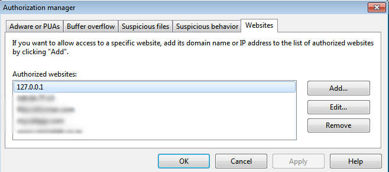

```python
display(Image(filename='images/sophos02.png'))
```

If the 127.0.0.1 loopback IP address does not appear in the list, add it as shown above.

Now close any ipython notebooks that you have, also the page at 127.0.0.1:8888. Close the command window and re-open a new one. Open a new tab and enter the local address 127.0.0.1:8888. This should display the notebooks in the current directory and once opened, they should work.

## Starting a new notebook

To create a new page click on the `New Notebook` button on the IPython notebook portal.

You can also make a copy of an existing page by selecting the appropriate menu option under the `File` menu.

## Notebook cells

The notebook comprises a 'behind-the-scene' kernel that does all the processing and a 'front-man' rendering in the browser window. It is important to understand that the web page browser does very little work, it only renders the information under instruction from the kernel. The kernel contains all the code, text and data.

The notebook consists of a number of cells which can contain code, text or other information. Each cell is 'executed' or 'run' by clicking on the cell and pressing the Shift-Enter key combination. Cells can also be run in sequence from the Cell menu entry. Running a cell does at least two things: (1) the cell changes/updates its data in the kernel and (2) the updated data is rendered in the browser window.

Writing the notebook becomes the process of creating cells and adding text or code to the cell.

The implication of running a complete notebook is that the full sequence of cells must be executed in the appropriate sequence. This is not always the case because you can manually execute a specific cell any number of times, without running its prior cells. Furthermore, it is allowed and often done that cells are moved up or down in the sequence. So the strict sequence is not always followed and this can lead to all sorts of difficulties, see Notebooks Remember

## Saving and closing the Notebook

The notebook is saved in its json format by saving from the IPython menu. Click on the save button (leftmost button with the mouse-over message 'Save and Checkpoint') or select the `File Save and Checkpoint` menu option.

The IPython notebook file is saved and closed by selecting the `File Close and Halt` menu option.

Never use an `exit()` function in yoour notebook, because the notebook will interpret this as an exit to its own process, closing down the server.

## Converting the notebook to other formats

### IPython built-in conversion

Starting from IPython 2, the notebook can be converted to a Python file (code with embedded comments), an HTML file or a ReST file. On the *File* menu, use *Download as*.

The notebook can also be saved to an HTML file by saving from your browser's menu. This saved HTML file is, however, not fully self-contained (images and JavaScript files are in a directory). So this is *not* the ideal way to save the file.

```python
HTML('<img src="images/convertfile.png" width=300 height=300/>')
```

[figure not shown]

### Command-line conversion

The notebook can be converted to $\LaTeX$ and then compiled to a PDF format with the following command:  
`ipython nbconvert --to latex --post filename.ipynb`

The $\LaTeX$ document style can be specified as follows:  
`ipython nbconvert --to latex filename.ipynb --template=article`  
once the tex document is ready run pdflatex:  
`pdflatex filename.tex`

http://ipython.org/ipython-doc/rel-1.0.0/interactive/nbconvert.html  
http://blog.fperez.org/2012/09/blogging-with-ipython-notebook.html  
http://nbviewer.ipython.org/url/www.damian.oquanta.info/posts/blogging-with-nikola-and-ipython.ipynb - blogging with Nikola  
http://www.slideviper.oquanta.info/tutorial/slideshow_tutorial_slides.html?transition=none#/ - slides  
http://www.damian.oquanta.info/ - a couple of links  
http://nbviewer.ipython.org/github/Carreau/posts/blob/master/06-NBconvert-Doc-Draft.ipynb - using the nbconvert API

### High-quality graphics in $\LaTeX$

By default the Matplotlib backend for IPython generates png files. The quality of these files are not all that good for publication. $\LaTeX$ uses Encapsulated PostScript (eps) files for publications, or PDF files in PDFLaTeX. It is possible to instruct the backend to render in Scalable Vector Graphics (svg) format by using: `%config InlineBackend.figure_format = 'svg'`  
The svg file is, however, not rendereable in $\LaTeX$ and must be converted to PDF for use in PDFLaTeX. In order to do the conversion you must have [Inkscape](http://www.inkscape.org/en/) on your PC (and on Windows the path to the inkscape executable must be on your PATH). The nbconvert process will convert the svg files created by Matplotlib/IPython to PDF files using Inkscape on your PC.

http://ipython.org/ipython-doc/rel-1.0.0/interactive/nbconvert.html  
https://stackoverflow.com/questions/19659864/ipython-nbconvert-and-latex-use-eps-instead-of-png-for-plots  
https://stackoverflow.com/questions/19600234/nbconvert-pdf-latex-page-formatting-ipython  
https://stackoverflow.com/questions/19524554/suppress-code-in-nbconvert-ipython

## Notebook viewer on the internet

There is a website nbviewer.ipython.org/ that will convert a notebook from ipynb format to html and display it in your browser. Just browse over to http://nbviewer.ipython.org/ and enter the URL of the notebook you want to view.

A particularly useful feature of http://nbviewer.ipython.org/ is that you can add the GitHub username of someone and then can view all the notebooks by that user.

Alternatively, you can build a composite URL such as follows to view a notebook. The following example shows this current notebook in the viewer.

`HTML('<iframe src=http://nbviewer.ipython.org/github/NelisW/ComputationalRadiometry/blob/master/01-IPythonHintsAndTips.ipynb width=700 height=350></iframe>')`

```python
HTML('<iframe src=http://nbviewer.ipython.org/github/NelisW/ComputationalRadiometry/blob/master/01-IPythonHintsAndTips.ipynb width=700 height=350></iframe>')
```

[interactive chart not shown]

## Keyboard Shortcuts

Here is the complete set of keyboard shortcuts available:

| **Shortcut** | **Action** |  | **Shortcut** | **Action** |
| --- | --- | --- | --- | --- |
| Shift-Enter | run cell |  | Ctrl-m l | toggle line numbers |
| Ctrl-Enter | run cell in-place |  | Ctrl-m s | save notebook |
| Alt-Enter | run cell, insert below |  | Ctrl-m j | move cell down |
| Ctrl-m x | cut cell |  | Ctrl-m k | move cell up |
| Ctrl-m c | copy cell |  | Ctrl-m y | code cell |
| Ctrl-m v | paste cell |  | Ctrl-m m | markdown cell |
| Ctrl-m d | delete cell |  | Ctrl-m t | raw cell |
| Ctrl-m z | undo last cell deletion |  | Ctrl-m 1-6 | heading 1-6 cell |
| Ctrl-m - | split cell |  | Ctrl-m p | select previous |
| Ctrl-m a | insert cell above |  | Ctrl-m n | select next |
| Ctrl-m b | insert cell below |  | Ctrl-m i | interrupt kernel |
| Ctrl-m o | toggle output |  | Ctrl-m . | restart kernel |
| Ctrl-m O | toggle output scroll |  | Ctrl-m h | show keyboard shortcuts |

http://ipython.org/ipython-doc/stable/interactive/notebook.html#keyboard-shortcuts

## Magics and System Commands

IPython has a set of predefined ‘magic functions’ that you can call with a command line style syntax. There are two kinds of magics, line-oriented and cell-oriented. Line magics are prefixed with the % character and work much like OS command-line calls: they get as an argument the rest of the line, where arguments are passed without parentheses or quotes. Cell magics are prefixed with a double %%, and they are functions that get as an argument not only the rest of the line, but also the lines below it in a separate argument.

http://nbviewer.ipython.org/github/ipython/ipython/blob/master/examples/notebooks/Cell%20Magics.ipynb  
http://ipython.org/ipython-doc/dev/interactive/tutorial.html#magic-functions  
http://damontallen.github.io/IPython-quick-ref-sheets/

System commands (as you would normally type in a command window) can be executed by prepending with an exclamation mark.

```python
import os
# see if this is Linux or Windows
if os.path == '/':
    !ls *.ipynb
else:
    !dir *.ipynb
```

```
 Volume in drive C is SYSTEM
 Volume Serial Number is 98E8-BF6A

 Directory of C:\WorkT\Notebooks\ComputationalRadiometry

2014-06-09  14:39           573ÿ980 01-IPythonHintsAndTips.ipynb
2014-06-18  11:15           460ÿ907 02-PythonWhirlwindCheatSheet.ipynb
2014-06-01  14:35           717ÿ093 03-Introduction-to-Radiometry.ipynb
2014-06-01  14:34         1ÿ356ÿ502 04-IntroductionToComputationalRadiometryWithPyradi.ipynb
2014-06-01  19:48           805ÿ996 05a-PlottingWithPyradi-GeneralAndCartesian.ipynb
2014-06-01  14:33         3ÿ067ÿ518 05b-PlottingWithPyradi-Polar-and-3D.ipynb
2014-06-01  14:33            92ÿ435 06-Diverse-pyradi-utilities.ipynb
2014-06-01  14:33           968ÿ737 07-Optical Sources.ipynb
2014-06-01  14:33           447ÿ061 08-ModtranFileProcessing.ipynb
2014-06-01  14:33           179ÿ111 09-DetectorModelling.ipynb
2014-06-01  14:32           521ÿ247 10-ImageUtilities.ipynb
2014-06-02  07:53         3ÿ176ÿ245 11-InfraredMeasurementAndAnalysis.ipynb
2014-06-01  14:34           309ÿ065 12a-FlameSensorAnalysis.ipynb
2014-06-01  14:30         3ÿ593ÿ225 12b-AlbedoDerivation.ipynb
              14 File(s)     16ÿ269ÿ122 bytes
               0 Dir(s)  91ÿ529ÿ302ÿ016 bytes free
```

There are 'magics' to support a number of other languages in the IPython notebook. From the [IPython notebook website](http://ipython.org/):

"We ship the official IPython kernel, but kernels for other languages such as Julia and Haskell are actively developed and used. Additionally, the IPython kernel supports multi-language integration, letting you for example mix Python code with Cython, R, Octave, and scripting in Bash, Perl or Ruby."

http://andrew.gibiansky.com/blog/ipython/ipython-kernels/  
http://ipython.org/ipython-doc/stable/development/messaging.html

Several extensions also exist to access other software tools from within IPython:  
http://ipython.org/ipython-doc/dev/config/extensions/  
http://nbviewer.ipython.org/github/jrjohansson/ipython-asymptote/blob/master/Asymptote-examples.ipynb for [Asymptote](http://asymptote.sourceforge.net/)  
http://www2.ipp.mpg.de/~mkraus/python/tikzmagic.py and http://www2.ipp.mpg.de/~mkraus/python/tikzmagic_test.ipynb for [tikz](http://www.texample.net/tikz/examples/).

## Magics for general use

List all the magics currently available

```python
%lsmagic
```

```
Available line magics:
%alias  %alias_magic  %autocall  %automagic  %autosave  %bookmark  %cd  %clear  %cls  %colors  %config  %connect_info  %copy  %ddir  %debug  %dhist  %dirs  %doctest_mode  %echo  %ed  %edit  %env  %gui  %hist  %history  %install_default_config  %install_ext  %install_profiles  %killbgscripts  %ldir  …

Available cell magics:
%%!  %%HTML  %%SVG  %%bash  %%capture  %%cmd  %%debug  %%file  %%html  %%javascript  %%latex  %%perl  %%powershell  %%prun  %%pypy  %%python  %%python2  %%python3  %%ruby  %%script  %%sh  %%svg  %%sx  %%system  %%time  %%timeit  %%writefile

Automagic is ON, % prefix IS NOT needed for line magics.
```

Use the `%%file` magic to write contents to a file:

```python
%%file test.txt
This is a test file!
It can contain anything I want...

more...
```

```
Overwriting test.txt
```

```python
with open('test.txt', 'r') as fi:
    print('{}'.format(' '.join(fi.readlines())))
```

```
This is a test file!
 It can contain anything I want...

 more...
```

## Magics for using IPython for numeric and scientific work

Early tutorials advised that you start the IPython kernel with the `--pylab=inline` option to load a bunch of packages and see Matplotlib graphs in the browser. As from IPython 2.0, the server advises you not to use this option, because it pre-loads a number of modules and packages that may not be required and may even interfere with your intended work.

**Don't use `%pylab` either:** Then there is the `%pylab` magic command, which essentially does the same as the `--pylab=inline` option. The full command is [`%pylab [--no-import-all] [gui]`](http://ipython.org/ipython-doc/stable/api/generated/IPython.core.magics.pylab.html). When using this magic, IPython loads numpy and matplotlib. The following libraries are imported in this magic:

```
import numpy
import matplotlib
from matplotlib import pylab, mlab, pyplot
np = numpy
plt = pyplot

from IPython.display import display
from IPython.core.pylabtools import figsize, getfigs

from pylab import *
from numpy import *
```

Clearly the last two imports could potentially cause namespace conflicts with other modules. This is because `import *` is [not good practice](https://stackoverflow.com/questions/2386714/why-is-import-bad). If you use the form `%pylab -–no-import-all` the last two * imports will not be executed. So the `%pylab` magic command could be something like `%pylab -–no-import-all inline` to get inline plots in the notebook.

But this method still clutters the IPython interactive namespace with global pylab names, potentially causing problems.

**Use `%matplotlib` instead:** Do use the `%matplotlib [gtk|gtk3|inline|osx|qt|qt4|tk|wx]` magic to define the Matplotlib plotting backend without importing anything into the IPython interactive namespace. For the full discussion [see here](http://carreau.github.io/posts/10-No-PyLab-Thanks.ipynb.html). So the preferred method to get Matplotlib graphics inline in the notebook is to use the magic command  
`%matplotlib inline`  
After using this magic, you still have to import numpy manually.

Note that the file format to which Matplotlib renders a graphic can be set by the following magic:

`%config InlineBackend.figure_format = 'svg'` # svg format  
`%config InlineBackend.figure_format = 'png'` #standard resolution png  
`%config InlineBackend.figure_format = 'retina'` #high resolution png

https://stackoverflow.com/questions/17582137/ipython-notebook-svg-figures-by-default

## Optimising with IPython

https://robotwhale.wordpress.com/2014/08/17/optimization-with-ipython/

## Local files

If you have local files in your Notebook directory, you can refer to these files in Markdown cells via relative URLs that are prefixed with files/ as in:

files/[subdirectory/]filename

## Help

Introspection help is available by typing the object's name followed by a question mark, then execute the cell. Double click on the divider to close the help console.

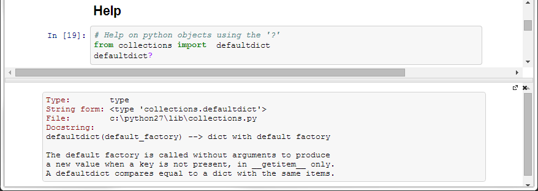

```python
from collections import  defaultdict
# defaultdict?
display(Image(filename='images/introspection.png'))
```

You can also access the built in Python help system, by typing help(objectname), and then execute the cell.

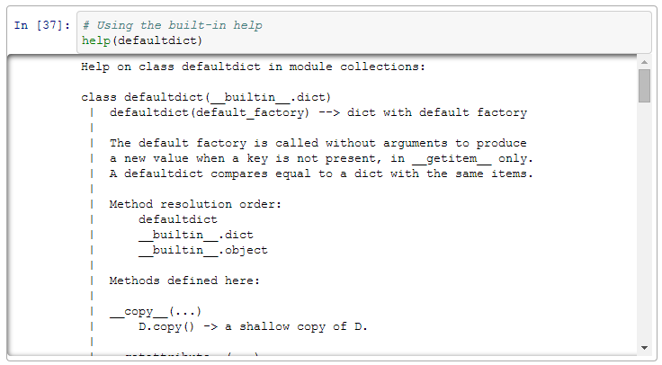

```python
# help(defaultdict)
display(Image(filename='images/python-help.png'))
```

Tab-completion help is also available, just press TAB after the period

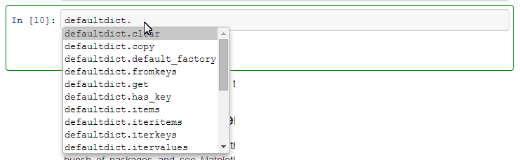

```python
# defaultdict.
display(Image(filename='images/tabcompletion.png'))
```

The IPython *Help* menu item has links to IPython and the scientific packages

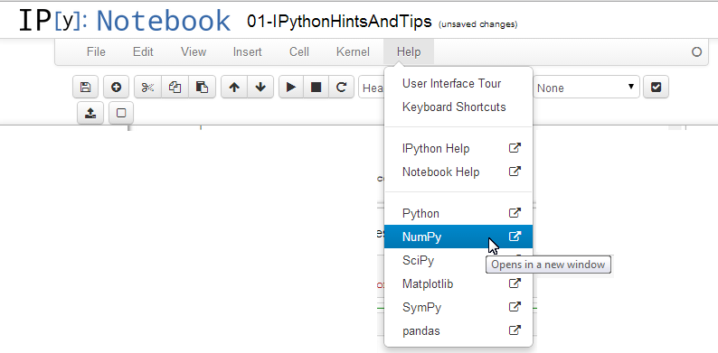

```python
display(Image(filename='images/ipythonhelp.png'))
```

## Notebooks remember, but not the way you might think

The notebook visible in the browser is not really the notebook, it is only a rendering of the notebook. The actual notebook and its data resides in the IPython kernel. The browser is connected to the kernel via a zmq channel, for the purpose of rendering and input. You can close all the browser windows, but the code and data still resides in the kernel process. As long as the kernel is running you can open a new browser window at 127.0.0.1:8888 and the notebook will be displayed.

The results (including graphs and images) from previous runs are recorded in the notebook, so when it is rendered the previously stored results are shown. The previous results are overwritten only if the cell is executed again.

Most important, the results from a previous cell execution remains in the kernel, even if the cell is removed or moved up in the notebook. It happens from time to time that you execute a cell in a given location, creating some data in the kernel. The next cell uses this information in a calculation. So far, so good. Now you decide to re-organise the notebook and move the 'next cell' to a position earlier in the notebook, even before the cell that created the information in the first place. The newly moved cell still works in its new location, because the information is still in memory. At the end of work, you save and close the notebook and exit the kernel.

Tomorrow you start a new kernel and load the notebook. To ensure that all is fresh and well, you decide to execute all cells in the notebook. But now the moved cell does not work, because its input information is not yet created - it is only created a few cells into the future. Yet it did work before (because of results still remaining in memory.

It is important to understand that the concept of the non-existence of data prior to cell execution does not apply if you move cells around in the notebook. All results are remembered and accessible by cells *linearly before* the cell that created the information.

Similarly, remember that a cell changes information for prosperity, also for subsequent runs of the same cell. For example, suppose we assign a value to a variable in the next cell and in the cell thereafter increment the value. If the first cell is executed once and the second cell is executed repeatedly, the value will increase much more than it would be if the program was executed from start to finish with each cell executed once only.

A similar error occurs if the first cell creates a table, and the second cell adds a new column to the table. If the second cell is repeated a number of times, many columns will be added, which was not the intention with the code (it happened to me using pandas).

Therefore be careful with cells that modifies its own input data - such data is not static and changes with each invocation of the cell.

```python
#run this cell once
a = 5
```

```python
#run this cell several times
a = a + 1
print(a)
```

```
6
```

## Clearing the IPython memory

If for some reason you need to clear out all memory in your notebook this can be done by selecting the `Kernel Restart` menu option. This will clear the kernel memory, including the memory of all open notebooks. So use this avenue with care. After restarting the kernel, all notebooks must be re-run from start to build the information again.

You can use the Cell | All Output | Clear menu option to *remove all output* from a notebook. It will be much smaller, but also empty of any output or embedded media. To see the full notebook, you would have to run all cells again.

## Reloading imports

Python's import facility loads a file only once, if the `import` is encountered again for the same module, the import is ignored. On ocassion the module to be imported may change after the first import. In this case you want to force another import execution. This can be done with the `%load_ext autoreload` magic command. If the extension is already loaded, Ipython may complain, so I use `%reload_ext autoreload`, which attempts to load or reload, as appropriate.

http://ipython.org/ipython-doc/rel-1.1.0/config/extensions/autoreload.html

```python
%reload_ext autoreload
%autoreload 2
import numpy as np
```

## Markdown (MD) language syntax

IPython uses the markdown syntax for text in its non-code cells. Markdown is a simplified syntax for simple text layout. When IPython creates a new cell it is a code cell by default, you must remember to change it to a markdown cell on the menu.

One confusing matter is the fact there are different variants of MD. For more details on the syntax see  
https://stackoverflow.com/editing-help  
http://nbviewer.ipython.org/github/ipython/ipython/blob/master/examples/notebooks/Part%204%20-%20Markdown%20Cells.ipynb http://johnmacfarlane.net/pandoc/demo/example9/pandocs-markdown.html  
http://johnmacfarlane.net/pandoc/README.html  
http://daringfireball.net/projects/markdown/  
http://daringfireball.net/projects/markdown/basics  
http://daringfireball.net/projects/markdown/syntax  
https://github.com/adam-p/markdown-here/wiki/Markdown-Cheatsheet  
http://support.iawriter.com/help/kb/general-questions/markdown-syntax-reference-guide

You can also use embedded raw HTML into a markdown page, but you need to type a lot more than in pure MD.

IPython uses the Pandoc converter to convert between different markup languages, so my guess is that it is prudent to work with the Pandoc variant of MD syntax (which is close to the original). The other major MD variant is the github MD syntax - which is somewhat different.

To force a newline end the current line with two spaces.

If your markdown does not want to work right, first try to leave a blank line before the offending text.

### Markdown Cells

Type this to get the output shown below:

```
Markdown basics: lists, markup and code

* list item
* list item
  * nested <font size="3" color="red">list item</font>


* *italics*
* **bold**
* `fixed_font`

You can embed code meant for illustration instead of execution in Python - use four spaces before:

    def hello_ipython():
        print "Hello IPython!"
```

Markdown basics: lists, markup and code

- list item
- list item
- nested list item
- *italics*
- **bold**
- `fixed_font`

You can embed code meant for illustration instead of execution in Python - use four spaces before:

```
def hello_ipython():
    print "Hello IPython!"
```

A key and important point is that IPython markdown can take embedded HTML of any form.  
Therefore in applications where the markdown syntax it too weak, use HTML. Be aware however that not all of the HTML constructs can be converted to some of the conversion output formats (e.g., embedding video in a $\LaTeX$ document).

Type this to get the output shown below:

```
Markdown cells can also contain HTML

<p>Markdown basics: lists, markup and code</p>

<ul>
<li>list item</li>
<li><p>list item</p>

<ul>
<li>nested <font size="3" color="red">list item</font></li>
</ul></li>
<li><p><em>italics</em></p></li>
<li><strong>bold</strong></li>

<li><code>fixed_font</code></li>
</ul>

<p>Code examples:</p>

<pre><code>def hello_ipython():
    print "Hello IPython!"
</code></pre>
```

Markdown cells can also contain HTML

Markdown basics: lists, markup and code

- list item
- list item
  - nested list item
- *italics*
- **bold**
- `fixed_font`

Code examples:

```
def hello_ipython():
    print "Hello IPython!"
```

Type this to get the output shown below:

```
Using math mode (anything between two `$`s or two `$$`s) is interpreted as $\LaTeX$ math:

$$ D_{KL}(P||Q) = \sum\limits_{i}ln (\frac{P(i)}{Q(i)}) P(i)$$
```

Using math mode (anything between two `$`s or two `$$`s) is interpreted as $\LaTeX$ math:

$D_{KL}(P||Q) = \sum\limits_{i}ln (\frac{P(i)}{Q(i)}) P(i)$

### Github markdown can also be used

The Notebook webapp support Github flavored markdown meaning that you can use triple backticks for code blocks

````
```python
print "Hello World"
```

```javascript
console.log("Hello World")
```
````

gives

```python
print "Hello World"
```

```javascript
console.log("Hello World")
```

And a table like this :

```
| This | is   |
|------|------|
|   a  | table|
```

gives

| This | is |
| --- | --- |
| a | table |

### Citations and links

Markdown syntax does not have any means to provide citations as often required in formal documentation.

Markdown hyperlinks to external websites: [pyradi](https://code.google.com/p/pyradi/) Python package. You can provide the display text, the ling address and amouse-over attribute.

HTML anchors can be used to create links to other locations in the same file. Put an anchor definition in the place you want to link to, using this format: `<a name="MyAnchor">`. It seems the best place to put this anchor is in a dedicated markdown cell immediatelty in front of where you want to link to, it does not work in a cell with other text. From elsewhere in the file link to this anchor by using the following format  
`<a href="#MyAnchor">my anchor</a>`

It is also possible to attach anchors to headers as explained in https://stackoverflow.com/questions/16630969/ipython-notebook-anchor-link-to-refer-a-cell-directly-from-outside

http://nbviewer.ipython.org/github/ipython/nbconvert-examples/blob/master/citations/Tutorial.ipynb - LaTeX citations in the notebook.

### Cross linking and table of contents

IPython does not yet support the automatic creation of a table of contents, but it can be added manually by placing an HTML anchor immediately before the section heading and then linking to the anchor. Note that in IPYthon the browser's 'back arrow' won't navigate back to the previous location in the page.

```
# Table of Contents

- [Overview](#Overview)
- [Learning Python and hints and tips](#LearningPythonandhintsandtips)
- [Introducing Python for scientific work](#IntroducingPythonforscientificwork)

<a name="Overview"></a>
##Overview

This notebook provides a brief summary ....

<a name="LearningPythonandhintsandtips"></a>
##Learning Python, and hints and tips

There are many free ....

<a name="IntroducingPythonforscientificwork"></a>
##Introducing Python for scientific work

A very good introduction to Python for scientific work ....
```

Table of Contents

- Overview
- Learning Python and hints and tips
- Introducing Python for scientific work

## IPython's rich display system

http://nbviewer.ipython.org/urls/raw.github.com/ipython/ipython/1.x/examples/notebooks/Part%205%20-%20Rich%20Display%20System.ipynb - IPython's rich display system.

### Plotting

IPython can inline [Matlibplots](http://matplotlib.org/). The pyradi library builds a wrapper around Matplotlib to provide for more compact code.

http://nbviewer.ipython.org/urls/raw.github.com/jakevdp/matplotlib_pydata2013/master/notebooks/05_Animations.ipynb - animations  
http://nbviewer.ipython.org/urls/raw.github.com/jakevdp/matplotlib_pydata2013/master/notebooks/03_Widgets.ipynb - interactivity  
http://nbviewer.ipython.org/github/dpsanders/matplotlib-examples/blob/master/colorline.ipynb - multi-colour lines

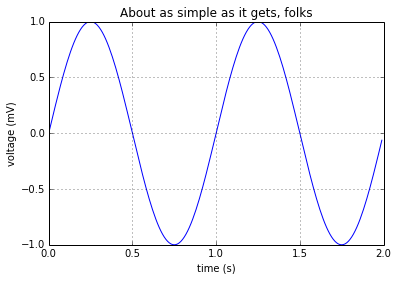

```python
%matplotlib inline

import pylab as pl
import numpy as np

t = np.arange(0.0, 2.0, 0.01)
s = np.sin(2*np.pi*t)
pl.plot(t, s)
pl.xlabel('time (s)')
pl.ylabel('voltage (mV)')
pl.title('About as simple as it gets, folks')
pl.grid(True)
# savefig("test.png")
# show()
```

### Matplotlib in qt window

Use the ipython magic command pylab to control the graphing backend, switch between inline and qt as required.  
http://stackoverflow.com/questions/14261903/how-can-i-open-the-interactive-matplotlib-window-in-ipython-notebook/14277370#14277370

### Including images into the notebook

There are (at least) two ways to include images in the notebook.

```
display(Image(filename='images/portalpage.png'))
HTML('<img src="files/images/portalpage.png" width=600 height=600/>')
```

The first form includes the image in its natural size, but the size can be adjusted by width and height function parameters. The second form injects HTML code and, likewise, allows you to set the image size.

```python
HTML('<img src="images/ipythonhelp.png" width=400 height=200/>')
```

[figure not shown]

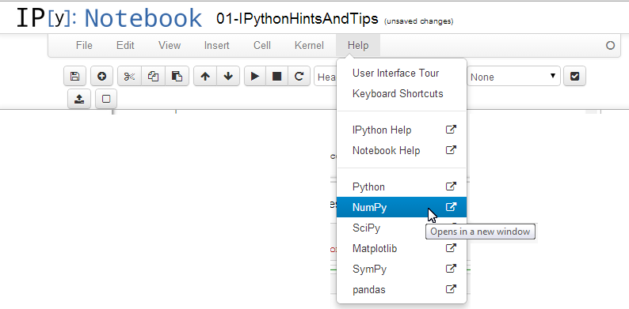

```python
display(Image(filename='images/ipythonhelp.png', width=250, height=250))
```

### Embedded vs non-embedded images

As of IPython 0.13, images are embedded by default for compatibility with QtConsole, and the ability to still be displayed offline.

http://www.slideviper.oquanta.info/nbcreveal/sky_test.html?theme=sky#/7

[figure not shown]

```python
# by default Image data are embedded
picUrl = 'https://pyradi.googlecode.com/svn/trunk/pyradi/doc/_images/pyradi.png'
Embed  = Image(picUrl)
display(Embed)

# if kwarg `url` is given, the embedding is assumed to be false
# SoftLinked = Image(url=picUrl)

# In each case, embed can be specified explicitly with the `embed` kwarg
# ForceEmbed = Image(url=picUrl, embed=True)
```

### Embedding other media

SVG graphic.

```python
from IPython.display import SVG
SVG(filename='images/solidangleflatplate.svg')
```

[figure not shown]

### Embed a video from YouTube.

```python
from IPython.display import YouTubeVideo
# a talk about IPython at Sage Days at U. Washington, Seattle.
# Video credit: William Stein.
YouTubeVideo('1j_HxD4iLn8')
```

[video not shown]

### Embed an external web page.

```python
HTML('<iframe src=https://en.wikipedia.org/wiki/Einstein width=700 height=350></iframe>')
```

[interactive chart not shown]

# The following information is somewhat esoteric, you need not go into this

### Notebook file format

From http://ipython.org/ipython-doc/stable/notebook/nbconvert.html#notebook-json-file-format

Binary data such as figures are also saved directly in the JSON file. This provides convenient single-file portability, but means that the files can be large; a diff of binary data is also not very meaningful. Since the binary blobs are encoded in a single line, they affect only one line of the diff output, but they are typically very long lines. You can use the Cell | All Output | Clear menu option to remove all output from a notebook prior to committing it to version control, if this is a concern.

### Reading json files in IPython

The following code reads this file and prints the first five cells.

```python
from IPython.nbformat import current
with open('01-IPythonHintsAndTips.ipynb') as f:
    nb = current.read(f, 'json')
```

```python
nb.worksheets[0].cells[0:5]
```

```
[{u'cell_type': u'heading',
  u'level': 1,
  u'metadata': {},
  u'source': u'1 IPython notebook hints and tips\n\n'},
 {u'cell_type': u'markdown',
  u'metadata': {},
  u'source': u'This notebook forms part of a series on [computational optical radiometry](https://github.com/NelisW/ComputationalRadiometry#computational-optical-radiometry-with-pyradi).  The notebooks can be downloaded from [Github](https://github.com/NelisW/ComputationalRadiometry#computational-op…
 {u'cell_type': u'markdown',
  u'metadata': {},
  u'source': u'The date of this document and module versions used in this document are given at the end of the file.  \nFeedback is appreciated: neliswillers at gmail dot com.'},
 {u'cell_type': u'heading',
  u'level': 2,
  u'metadata': {},
  u'source': u'<a name="Overview"></a>\nOverview'},
 {u'cell_type': u'markdown',
  u'metadata': {},
  u'source': u'This notebook provides a brief summary of how to start up and use the IPython notebook.\nIntroductions are given to magic commands, help functionality, using IPython for scientific work, cell memory, markdown, citations, embedding media files, and a few lesser used functions.\n'}]
```

### Running notebook servers

This document describes how you can secure a notebook server and how to run it on a public interface:  
http://ipython.org/ipython-doc/rel-1.1.0/interactive/public_server.html

### Markdown formatting in dynamic output display

http://catherinedevlin.blogspot.com/2013/06/easy-html-output-in-ipython-notebook.html

For this to work, you first have to install the Python markdown package (assuming you have the pip python package installer):  
`pip install markdown`

Use the following function to render a Python string in markdown syntax to display in IPython:

```python
import markdown
class MD(str):
    def _repr_html_(self):
        return markdown.markdown(self)
```

```python
import math
a = 2
MD("""
Dynamic demonstration
--------------
This is a mixture of markdown **and** html:<br>
The square root of {0} <span STYLE=color:green>used to be</span> somewhere near {1}""".format(a,math.sqrt(a)))
```

Dynamic demonstration

This is a mixture of markdown **and** html:  
The square root of 2 used to be somewhere near 1.41421356237

### HTML formatting in dynamic output display

Use HTML to format the output of your code http://python.6.x6.nabble.com/Printing-HTML-within-IPython-Notebook-IPython-specific-prettyprint-td5016624.html

```python
from IPython.display import display, HTML
for x in range(3):
    display(HTML("<i>Length</i> <b>" + str(x) + "</b>"))
```

*Length* **0**

*Length* **1**

*Length* **2**

### Displaying tables in HTML

http://calebmadrigal.com/display-list-as-table-in-ipython-notebook/

```python
class ListTable(list):
    """ Overridden list class which takes a 2-dimensional list of
        the form [[1,2,3],[4,5,6]], and renders an HTML Table in
        IPython Notebook. """

    def _repr_html_(self):
        html = ["<table>"]
        for row in self:
            html.append("<tr>")

            for col in row:
                html.append("<td>{0}</td>".format(col))

            html.append("</tr>")
        html.append("</table>")
        return ''.join(html)
```

```python
import random
table = ListTable()
table.append(['x', 'y', 'x-y', '(x-y)^2'])
for i in xrange(7):
    x = random.uniform(0, 10)
    y = random.uniform(0, 10)
    table.append([x, y, x-y, (x-y)**2])

table
```

| x | y | x-y | (x-y)^2 |
| --- | --- | --- | --- |
| 8.43532143637 | 7.48714981789 | 0.948171618477 | 0.899029418085 |
| 0.953562495284 | 0.0563958762074 | 0.897166619076 | 0.804907942385 |
| 7.43999790489 | 3.66692470057 | 3.77307320431 | 14.2360814051 |
| 8.10111675594 | 9.58809150411 | -1.48697474817 | 2.21109390169 |
| 9.08592664498 | 5.42301710898 | 3.66290953601 | 13.416906269 |
| 6.51355205806 | 1.8790951377 | 4.63445692036 | 21.4781909466 |
| 4.13968535812 | 4.18118346204 | -0.0414981039284 | 0.00172209262965 |

### More HTML formatting

http://stackoverflow.com/questions/13770394/ipython-notebook-make-output-cells-like-markdown

```python
htmlContent = ''

def header(text):
    raw_html = '<h1>' + str(text) + '</h1>'
    return raw_html

def box(text):
    raw_html = '<div style="border:1px dotted black;padding:2em;">'+str(text)+'</div>'
    return raw_html

def addContent(raw_html):
    global htmlContent
    htmlContent += raw_html


# Example
addContent( header("This is a header") )
addContent( box("This is some text in a box") )

from IPython.core.display import HTML
HTML(htmlContent)
```

This is a header

This is some text in a box

## Fine-tuning IPython typographic output appearance

Changing the fonts, colours and layout to suit your own style.  
http://slendrmeans.wordpress.com/2012/12/05/better-typography-for-ipython-notebooks/  
http://zulko.wordpress.com/2013/04/14/customize-your-ipython-notebook-with-css/

## Adding IPython display output to existing objects

http://nbviewer.ipython.org/url/github.com/ipython/ipython/raw/master/examples/notebooks/Custom%20Display%20Logic.ipynb

For example, define a function that pretty-prints a polynomial as a $\LaTeX$ string:

```python
def poly2latex(p):
    terms = ['%.2g' % p.coef[0]]
    if len(p) > 1:
        term = 'x'
        c = p.coef[1]
        if c!=1:
            term = ('%.2g ' % c) + term
        terms.append(term)
    if len(p) > 2:
        for i in range(2, len(p)):
            term = 'x^%d' % i
            c = p.coef[i]
            if c!=1:
                term = ('%.2g ' % c) + term
            terms.append(term)
    px = '$P(x)=%s$' % '+'.join(terms)
    dom = r', domain: $[%.2g,\ %.2g]$' % tuple(p.domain)
    return px+dom
```

```python
import numpy as np

p = np.polynomial.Polynomial([1,2,3], [-10, 10])
from IPython.display import Latex
Latex(poly2latex(p))
```

$P(x)=1+2 x+3 x^2$, domain: $[-10,\ 10]$

But you can instruct IPython to use default display as follows:

```python
ip = get_ipython()
latex_formatter = ip.display_formatter.formatters['text/latex']
latex_formatter.for_type_by_name('numpy.polynomial.polynomial',
                                 'Polynomial', poly2latex)
```

```python
p2 = np.polynomial.Polynomial([-20, 71, -15, 1])
p2
```

$P(x)=-20+71 x+-15 x^2+x^3$, domain: $[-1,\ 1]$

## Making slides from IPython notebooks

IPython is the tool of choice for presentations at Python conferences today - you hardly see a slideshow that was not made with IPython.  
http://www.slideviper.oquanta.info/tutorial/slideshow_tutorial_slides.html#/  
http://www.damian.oquanta.info/posts/make-your-slides-with-ipython.html  
http://nbviewer.ipython.org/github/fperez/nb-slideshow-template/blob/master/install-support.ipynb  
https://hannes-brt.github.io/blog/2013/08/11/ipython-slideshows-will-change-the-way-you-work/

Now one of the coolest new features are the Reveal.js based slideshows. [Here](http://www.slideviper.oquanta.info/tutorial/slideshow_tutorial_slides.html?transition=none#/) is an example by the developer of the slideshow feature Damián Avila which shows how to turn any IPython Notebook into a slideshow and how to include math, images, videos, tables, etc.

http://www.slideviper.oquanta.info/tutorial/slideshow_tutorial_slides.html?transition=none#/  
http://hannes-brt.github.io/blog/2013/08/11/ipython-slideshows-will-change-the-way-you-work/ - hiding code in slide shows.  
http://nbviewer.ipython.org/urls/gist.github.com/damianavila/5970218/raw/766d41eab9a16850a2a4447f14e93e7ed88f6b08/using_local_reveal.ipynb - local copy of reveal.js  
https://www.youtube.com/watch?v=rBS6hmiK-H8 - youtube video

First (1) create the IPython notebook as a regular notebook, then (2) change each cell's metadata to set its slideshow status, then (3) save the notebook, (4) convert the notebook to the slideshow format, and (5) serve the slideshow html file on an http server. Some of these steps are described next.

Step (2): Click on the the "Cell Toolbar" dropdown combobox: select the "Slideshow" option. On the top-right side of *each* cell will appear a dropdown combobox where you can define the slideshow status of that specific cell. Select the appropriate type for each cell.

Steps (4) and (5): The slide show runs in a reveal.js javascript environment, but requires that the file be served on an http server. In order to convert the notebook to slide show and serve in a browser, type the following command:  
`ipython nbconvert --to slides --post serve filename`  
where `filename` is the name of the ipython notebook you want to convert to a slide show.

## Blogging with IPython

IPython is also used to created blogging pages:  
http://blog.fperez.org/2012/09/blogging-with-ipython-notebook.html  
http://www.damian.oquanta.info/  
http://brunettoziosi.eu/posts/blogging-with-nikola-ipython-github.html  
http://www.davidketcheson.info/2012/10/11/blogging_ipython_notebooks_with_jekyll.html

## Customising the IPython notebook

The notebook is primarily rendered in HTML in the browser and when exported to HTML. As an HTML product it can be customised in terms of layout, font, colours and other elements of style. Likewise the exports to other formats, such as $\LaTeX$, can also be similarly customised to a particular look and feel.

http://slendermeans.org/better-typography-for-ipython-notebooks.html  
http://zulko.wordpress.com/2013/04/14/customize-your-ipython-notebook-with-css/  
http://nbviewer.ipython.org/github/Carreau/posts/blob/master/Blog1.ipynb

## Publishing your notebooks

If a notebook file (.ipynb) is available somewhere on the web, you can paste the URL into a text box on this website http://nbviewer.ipython.org/ and it will render the notebook for you, returning a URL to the HTML rendered file. This new URL can be embedded as a hyperlink in an HTML file - when the user clicks on the link, the browser will display the rendered notebook. This is how the notebooks referred to in the next section are rendered.

http://developer.rackspace.com/blog/bookstore-for-ipython-notebooks.html

## Python and [module versions, and dates](http://nbviewer.ipython.org/github/jrjohansson/scientific-python-lectures/blob/master/Lecture-0-Scientific-Computing-with-Python.ipynb)

From: [Introduction to scientific computing with Python](http://nbviewer.ipython.org/github/jrjohansson/scientific-python-lectures/blob/master/Lecture-0-Scientific-Computing-with-Python.ipynb) we learn: "To encourage the practice of recording Python and module versions in notebooks, I've created a simple IPython extension that produces a table with versions numbers of selected software components. I believe that it is a good practice to include this kind of table in every notebook you create. To install this IPython extension, run:"

```
# you only need to do this once
%install_ext http://raw.github.com/jrjohansson/version_information/master/version_information.py
```

Now, to load the extension and produce the version table

```python
%load_ext version_information
%version_information numpy, scipy, matplotlib
```

| Software | Version |
| --- | --- |
| Python | 2.7.7 (default, Jun 1 2014, 14:17:13) [MSC v.1500 32 bit (Intel)] |
| IPython | 2.1.0 |
| OS | nt [win32] |
| numpy | 1.8.1 |
| scipy | 0.13.3 |
| matplotlib | 1.3.1 |
| Wed Jun 18 11:17:01 2014 South Africa Standard Time |  |